# Factors that influence the level of weed seed predation: A review - Sarabi - 2019 - Weed Biology and Management - Wiley Online Library

[Weed Biology and Management](https://onlinelibrary.wiley.com/journal/14456664)

[Volume 19, Issue 3](https://onlinelibrary.wiley.com/toc/14456664/2019/19/3) p. 61-74

[figure not shown]

Review Paper

Open Access

# Factors that influence the level of weed seed predation: A review

[Vahid Sarabi](https://onlinelibrary.wiley.com/action/doSearch?ContribAuthorRaw=Sarabi%2C+Vahid),

First published: 05 September 2019

https://doi.org/10.1111/wbm.12186

Citations: 17

*Communicated by Hiroyuki Kobayashi*

## Abstract

Herbicides applied alone have failed to reduce weed populations in agricultural ecosystems. The use of this management strategy has followed other problems such as damage to ecosystems and organisms that live in it. Herbicide resistance in weeds has also occurred more quickly based on the application of herbicides. Today, most scientists are looking for new integrated weed management programs in agricultural ecosystems. Biological control is one of the most effective ways of weed management. In this way, living organisms are used to reduce and control weed species in arable lands. Weed seed predators, including predispersal and postdispersal predators as biological control agents, can be primary factors of weed seed mortality in agricultural ecosystems. This review has discussed factors influencing seed predator populations, activity, and granivory. Knowledge of the interrelations between factors and seed predators can contribute to designing future strategies that augment weed seed predator activity and enhance weed seed consumption as a component of an integrated weed management system.

Seed predation can be considered as one of the most important ways to suppress weed seeds from agricultural ecosystems. Predators that exploit weed seeds as an important food source (Fenner 1985) can lead to suppression of annual weeds in crop fields (Zhang *et al*. 1997; Cromar *et al*. 1999). Many researchers have reported that seed loss caused by eating by predators can be significant (Zhang *et al*. 1997), but differs between and within years (Cardina *et al*. 1996; Tooley *et al*. 1999), and fields (Mittelbach & Gross 1984; Hulme 1994; Menalled *et al*. 2000). As a result of this variation, crop producers might not be convinced that predation has a worthwhile effect on weed population suppression and largely ignore it. However, researchers have shown that weed management is an essential challenge in all farming systems to reduce weed seed densities by predators. For example, Mauchline *et al*. (2005) found greater than 70% predation of common chickweed [*Stellaria media* (L.) Vill.], prostrate knotweed (*Polygonum aviculare* L.), common lambsquarters (*Chenopodium album* L.), and wild mustard (*Sinapis arvensis* L.) over a 2-wk assay period conducted coincident with natural seed rain. Based on Zhang *et al*. (1997) research studies, reports of 90% or greater seed removal or damage are not unusual for certain weed species. Estimates of cumulative seed losses due to seed predators have ranged from 20% for barnyardgrass [*Echinochloa crus-galli* (L.) Beauv.], and common lambsquarters in a chisel plow system (Cromar *et al*. 1999) to 88% for giant ragweed (*Ambrosia trifida* L.) in no-tillage (Harrison *et al*. 2003). Overall, an annual seed loss of 25–50% seems to be enough to slow down weed population growth substantially (Medd & Ridings 1989). Besides, seasonal population fluctuations (Honek *et al*. 2006), phenological changes in predators life cycle (e.g., overwintering stages, breeding season, dispersal etc.), biotic factors such as high-level trophic interactions (Davis & Raghu 2010), the presence of alternative food sources (Frank *et al*. 2010, 2011), abiotic factors such as temperature (Saska *et al*. 2010), seed distribution patterns on the soil surface (Noroozi *et al*. 2012), and the method of seed exposure in the field (Shuler *et al*. 2008; Saska *et al*. 2014) can be attributed to levels of weed seed predation in the field.

Based on this ability, the main purpose of this review was highlighting the potential of predispersal and postdispersal weed seed predators in agricultural ecosystems and the factors that influence the level of weed seed predation under field conditions.

Weed seed predators are classified into two groups: those which feed immature and mature seeds before shed from the parent plant are called predispersal predators, and those which feed after shed on the soil surface are called postdispersal predators. Both vertebrates (e.g., birds and rodents) and invertebrates (e.g., ground beetles, ants, crickets, and slugs) feed on weed seeds (Brust & House 1988; Cardina *et al*. 1996; Zhang *et al*. 1997; Cromar *et al*. 1999), but differences in seed predator groups shift the magnitude of seed predation between different plant species (Dudenhoffer *et al*. 2016). For example, Honek *et al*. (2017) reported that invertebrate predation is an important factor of weed and seedling mortality of shining orache (*Atriplex sagittata* Borkh.) and seed heteromorphism modifies its intensity and timing.

## Predispersal Weed Seed Predators

Predispersal seed predation is more important and effective than postdispersal predation in weed suppression programs, because weed seeds are more vulnerable at this stage compared to after ripening. At least, 95% of all seed mortality occurs during the period between ovule formation and seed ripening, which is clearly the most susceptible stage in a weed's life history (Fenner 1985). Most predispersal predators are generally specialist insects, specific to one plant species, genus, or family and often belong to the orders Diptera, Lepidoptera, Coleoptera, and Hymenoptera (Crawley 1992). Kolb *et al*. (2007) stated that predispersal seed predation varies over space and time. If a seed predator consistently shifts plant population growth from increasing to decreasing in one habitat, but not in another, then the plant will be less frequent or even absent in the first and more common in the second habitat. On the other hand, if the seed predator substantially reduces plant population growth only in some years and in varying sites, its longer-term effect on the distribution pattern of the plant may be more diffuse. Sheppard *et al*. (1994) stated that a predispersal seed predation by moth larvae (Lepidoptera) causes variable control of musk thistle (*Carduus nutans* L.) ranging from 0 to 11%. Nurse (2000) reported that larvae of the microlepidopteran, *Coleophora lineapulvella* Chambers (Coleophoridae), feeds on the maturing seeds of redroot pigweed (*Amaranthus retroflexus* L.). This larva also feeds on the seeds of other *Amaranthus* genus such as smooth pigweed (*Amaranthus hybridus* L.) and powell amaranth (*Amaranthus powellii* S. Wats.)(Weaver & McWilliams 1980). Predispersal predation of redroot pigweed by *Coleophora lineapulvella* (Coleophoridae) was highly variable, with 11 and 3% of inflorescences attacked in 2 years of study; though the proportion of damaged seeds within inflorescences attacked was 93 and 42%, respectively (DeSousa *et al*. 2003). Louda (1982, 1983) reported that combination of predatory larvae, including tephritid flies, wasps, and micromoths, results in more than 90% seed mortality in two shrubs, sawtooth goldenbush (*Haplopappus squarrosus* Hook. & Arn.) and carquinez goldenbush (*Haplopappus venetus* H.M. Hall)(Asteraceae). In another research study, Lamp and McCarty (1982) found the larvae of two tephritid flies, *Orellia occidentalis* and *Paracantha culta*, and a pyralid moth, *Homeosoma stypticellum*, destroyed 21–54% of developing prairie thistle (*Cirsium canescens* Nutt.) seeds. The fly *Orellia ruficauda* preys on another species in the *Cirsium* genus and was observed on 20–85% of Canada thistle [*Cirsium arvense* (L.) Scop.] inflorescences and resulted in 20–80% of seeds' mortality (Forsythe & Watson 1985). Boieiro *et al*. (2010) reported that predispersal losses caused by specialist seed-wasp, *Eurytoma jaltica*, and generalist hemipterans (*Cydnus aterrimus* and *Dicranocephalus agilis*) were on average higher for the rare spurge (*Euphorbia welwitschii*) than common spurge (*Euphorbia characias*). They also stated that the substantial effect of predispersal seed predators might be due to low resource availability (low seed production by *E. welwitschii* and the absence of the alternative host). Many insects are attracted to host plants that have more flowers, larger inflorescences, or greater densities or biomass (Brody & Mitchell 1997). Fenner *et al*. (2002) reported that larval infestations on species of the Asteraceae family increase with capitulum size. Similarly, Ehrlén (1996) reported that spring vetch (*Lathyrus vernus* L. Bernh)(Leguminosae) seed predation was greater on plants with larger inflorescences. The inflorescence of redroot pigweed is composed of a dense branching panicle with many tightly packed flowers (Weaver & McWilliams 1980). This provides space and resources for numerous micromoth larvae to survive and overwintering. Unlike redroot pigweed, the inflorescence of common lambsquarters may not be suitable to support large populations of predatory larvae. Although it has a branching panicle, flowers are not densely packed (Bassett & Crompton 1978), and thus it may accommodate fewer larvae. Larvae of *Scrobipalpa atriplicella* (Roeslerstamm) (Lepidoptera: Gelechiidae) are a seed predator of common lambsquarters, but may quickly leave the inflorescence and burrow into the stem of the plant where they pupate thereby reducing predation (Bautista-Martínez *et al*. 1995). Studies have shown that chemical cues also play a major role in host plant selection by seed-wasp. Seed-wasp females are attracted from a distance by odors from fruits of their host plants, and the same substances also proved to play a vital role in eliciting oviposition (Kouloussis & Katsoyannos 1994).

## Postdispersal Weed Seed Predators

Postdispersal seed predation occurs at the soil surface after weed seeds have been shed and contribute to weed suppression. In contrast to predispersal predators, postdispersal predators include a wide range of vertebrates and invertebrates (Chambers & MacMahon 1994). Understanding the variety of taxa that contribute to seed removal is important because they may be locally important (Koprdova *et al*. 2010). Birds, rodents, and many invertebrates, including ground beetles (Zhang *et al*. 1997), ants (Mittelbach & Gross 1984), and crickets, have been classified as granivores and thus potential postdispersal weed seed predators. In agricultural ecosystems; mice, ground beetles, or ants are usually the main groups of organisms responsible for the destruction of weed seeds resulting from their soil surface activities (Cardina *et al*. 1996; Cromar *et al*. 1999). These and other organisms have different mobility, food and habitat preferences, and population dynamics and may, therefore, respond differently to farming practices (Westerman *et al*. 2003a). Hence, we evaluated the potential of these vertebrates and invertebrates that have been known as proper seed predators:

Some granivorous birds have an important role in the reduction of weed seedbanks. While birds are not the main seed consumers; they have an impact on the reduction of weed seeds from borders and crop fields. Birds are seen more in arable fields than the field borders compared to other predators. Holmes and Froud-Williams (2005) observed different patterns for seed predation by birds and other granivores in winter wheat (*Triticum aestivum* L.) crops in the South-East of England. Based on their observations, birds often feed on seeds from the crop fields up to between 15 and 25 m inwards from the field borders, while other predators, especially mice feed on seeds that were closer to field borders. Several studies have indicated that most granivorous beetles and rodents prefer denser vegetation (Manson & Stiles 1998; Honek & Jarosik 2000; Shearin *et al*. 2008) than granivorous birds and ants, which may prefer open patches (Moorcroft *et al*. 2002; Butler *et al*. 2005). Besides, birds cause the least seed loss in summer before crop harvest. Crop canopies presumably prevent birds reaching the soil surface at this time of the year and, therefore, unable to feed on weed seeds. Management of fields after crop harvest to encourage granivorous birds may actually help increasing postdispersal weed seed mortality (Holmes & Froud-Williams 2005), but it should be considered that birds may be caused to a reduction in yield if weed seeds were not available for them especially before crop harvest.

The relative importance of the different weed seed predator groups differs among habitats and may be changed over time (Menalled *et al*. 2000). Many rodents use the arable fields during summer (Birney *et al*. 1976), but return to the field boundaries in winter (Pollard & Relton 1970). Of course, mice show no tendency to migrate out of the fields when alternative habitat, such as woodlots and hedges, is lacking (Green 1979; Harris & Woollard 1990). Rodents often prefer areas where there is sufficient vegetation to escape from their enemies. Povey *et al*. (1993) studies indicated that rodents, especially mice, were the most important seed predators in field boundaries. However, Westerman *et al*. (2011) reported that rodent predation within fields is expected to increase later in the season with increasing crop development. Mice have a high dispersal rate, which enables them to colonize quickly in arable fields (Harris & Woollard 1990) and seek areas with high food density (Angelstam *et al*. 1987) or preferred food source (Tew *et al*. 2000). Granivorous rodents can move several hundred meters during a single night and may be able to distinguish between large differences in seed density within or between fields scale (Tew *et al*. 2000). Rodents can detect seeds; especially weed seeds by using their senses. Discrimination of unfilled vs. filled involucres (the actual dispersal unit of giant ragweed seed, which is a fruit consisting of fused, hardened bracts enclosing a single achene) may have been based on chemical cues or involucres' weight (Harrison *et al*. 2003). Other researchers have also reported that rodents use olfactory stimuli produced by seeds to find seeds buried in the soil (Vander Wall 1998).

Ground beetles and other ground-dwelling invertebrates have a much lower dispersal rate than rodents (Westerman *et al*. 2003a). However, carabid beetles (Coleoptera: Carabidae) are significant generalist predators in annual row-crop agricultural systems (Lee *et al*. 2001; Harrison *et al*. 2003; Gallandt *et al*. 2005). Invertebrates like beetles feed on weed seeds close to the center of the fields in addition to field boundaries (Cromar *et al*. 1999; Tooley *et al*. 1999), although Westerman *et al*. (2003a) observed no apparent pattern of predation by vertebrates and invertebrates related to field boundaries. Several carabid species eat remarkable numbers of weed seeds under laboratory and field conditions (Lund & Turpin 1977; Harrison *et al*. 2003). Holland (2002) reported that six species of carabid beetles known to consume weed seeds (i.e., *Harpalus pensylvanicus*, *Bembidion quadrimaculatum oppositum*, *Pterostichus melanarius*, *Chlaenius tricolor*, *Harpalus herbivagus*, and *Bembidion rapidum*). *Harpalus rufipes* also is a polyphagous ground beetle that has been identified as a potentially important weed seed predator (Zhang *et al*. 1997). Its activity–density was greater in vegetated treatments than in treatments lacking vegetation and varied among the vegetated treatments. Its greater activity–density was in oat–red clover and red clover (*Trifolium pretense* L.) sod than winter squash (*Cucurbita maxima* Duchesne)(38 vs. 26 trap<sup>−1</sup> 48 h<sup>−1</sup>, respectively; *P* < 0.001)(Gallandt *et al*. 2005). Honek *et al*. (2009) reported that carabids (*Amara*, *Anisodactylus*, *Harpalus*, *Pseudophonus rufipes*, and *Ophonus azureus*) are the most important predators of dandelion (*Taraxacum officinale* L.) seeds with consumption of 1–2 orders of magnitude greater than that of other predators. Saska *et al*. (2010) indicated the larger *Pseudoophonus rufipes* consumed more seeds (29.0 seeds day<sup>−1</sup>) than the smaller *Harpalus affinis* (average 12.2 seeds day<sup>−1</sup>) and within species, females consumed more seeds than males due to their larger bodies. They also reported that seed consumption by both sexes of *H. affinis* increased over a range of temperature or no response has been seen above the optimum temperature (20°C) by *P. rufipes*. In addition to adult carabids consuming seeds, carabid larvae are known to consume and cache a variety of weed seeds (Kirk 1972; Hartke *et al*. 1998). First, second and third instar larvae of members of the genus *Harpalus* have been shown in a laboratory study to eat all species of the most common weed seeds found in maize, *Zea mays* L. (Hartke *et al*. 1998).

Among ants, those belonging to genera *Rhytidoponera*, *Iridomyrmex*, *Meranoplus*, *Tetramorium*, *Cardiocondyla*, *Pheidole*, *Monomorium*, and *Melophorus* have been noted to consume seeds as part of their diet (Shattuck 1999). Chauhan *et al*. (2010) also indicated that weed seeds were removed from the soil surface at a high rate, and invertebrates, especially fire ants, *Solenopsis geminate*, were the main seed predators. The spatial distribution of nests may determine seed cache encounter probability by ants. Diaz (1992) reported a 50% decrease in foraging efficiency at distances more than 1.5 m from the nest for *Messor capitatus* Latreille. Harvester ant mobility and foraging activity could be enhanced by increasing soil temperature and moisture content of the soil surface (Azcarate *et al*. 2007). Soil temperatures could be increased by removing mulches or straw from the soil surface (Nkem *et al*. 2002), albeit, at the expense of loosing soil moisture.

Crickets were the most abundant invertebrate seed predators in Iowa and two species of crickets; fall field cricket, *Gryllus pennsylvanicus*, and Allards' ground cricket, *Allonemobius allardi*, accounted for nearly 98% of the invertebrates that were collected and considered as seed predators (O'Rourke *et al*. 2006). Brust (1994) has reported that *G. pennsylvanicus* inhabited low-input, no-tillage agroecosystems in high density. This cricket is known to feed on the seeds of various weeds, including giant foxtail (*Setaria faberi* Herrm.) and large crabgrass [*Digitaria sanguinalis* (L.) Scop.] (Lundgren & Rosentrater 2007; White *et al*. 2007). Ichihara *et al*. (2012) showed that the proportion of seedling emergence of Italian ryegrass (*Lolium multiflorum* Lam.) decreased with an increase in cricket density. They also suggested that in fields where the seedbank density of Italian ryegrass is low, such as during the initial stage of invasion of weed, seed predation by crickets probably influences the population of Italian ryegrass strongly.

In addition to the ability of predispersal and postdispersal seed predators; there are other factors affecting seed predation such as agricultural management practices and habitat structure.

## Factors Affecting Weed Seed Consumption Under Field Conditions

### Agricultural Management Practices

The intensity of seed predation is highly heterogeneous in the agricultural ecosystems based on management practices (Mittelbach & Gross 1984). Differential effects of seed burial (Hulme 1994; Hulme & Borelli 1999) and tillage (Cromar *et al*. 1999) have been reported to affect the intensity of seed predation. Studies have shown that factors such as soil cultivation pattern (Tyler & Ellis 1979; Holliday & Hagley 1984; Carcamo *et al*. 1995), cropping system (Dritschilo & Wanner 1980; Kromp 1989, 1990; Booij & Noorlander 1992; Carcamo *et al*. 1995; Carmona & Landis 1999; Blubaugh *et al*. 2011), and the use of pesticides (Lee *et al*. 2001; Marko & Kadar 2005) can influence seed predator activity.

### Tillage

Weed seeds are usually removed from the soil surface by tillage, especially by stubble cultivation and ploughing after crop harvest and buried at various depths in the soil profile (Cousens & Moss 1990). Scherner *et al*. (2016) reported that noninversion tillage caused the majority of the grass seeds (*Apera spica-venti* and annual fescue [*Vulpia myuros* (L.) C.C. Gmel]) being accumulated in the upper soil layers, at 0–5 and 5–10 cm and markedly less so in the 10–20 cm layer and ploughing resulted in a more even distribution between the three layers. Hulme (1994) reported that by postcultivation, weed seeds become largely unavailable for predation. In no-till fields, weed seeds may be subject to relatively high predation, because more of them are left exposed on the soil surface. For example, Italian ryegrass seeds in tilled fields were buried deeper in the soil by tillage, whereas seeds in the no-till fields were more prevalent near the soil surface (Ichihara *et al*. 2010). In another study, up to 88% of giant ragweed seeds were removed within 1 year of exposure on the soil surface of a no-tillage maize field in Ohio (Harrison *et al*. 2003), and up to 70% of the weed seeds shed in cereal fields in the Netherlands were removed during one growing season (Westerman *et al*. 2003b). Navntoft *et al*. (2009) also reported that at the field edge and 9 m distance from the field edge, the seed losses of common lambsquarters and common field-speedwell (*Veronica persica* Poir.) were higher at organic sites compared with conventional ones. Brust and House (1988) found that field mice such as *Peromyscus maniculatus* (Wagner) were substantial predators in a no-till system but not in the tilled system. Menalled *et al*. (2007) reported that seed predating carabid species, such as *Anisodactylus rusticus* and *Amara aenea* (De Geer), were associated with the no-till system. Their results also showed that more seeds were removed in the no-till system in comparison with the conventional or organic systems for fall panicum (*Panicum dichotomiflorum* Michx.), and common lambsquarters. Habitat management aimed at conserving and promoting ant nest and densities may be met with heightened enthusiasm (Chauhan *et al*. 2010). The shallow nests of young colonies of ants are particularly vulnerable to soil disturbance, such as tillage and ploughing. In reduced or no-till systems, soil disturbance is lower, thus positively influencing the survival chances of young colonies of ants (Baraibar *et al*. 2011). The equipment used for tillage operations determines the extent of soil disturbance and its ultimate effect on seed predators, especially carabid populations (Kulkarni *et al*. 2015). Studies indicate that soil disturbance and subsequent damage to granivorous beetles was lower when a chisel plow was used under a minimum tillage regime, compared to the disturbance caused by a moldboard plow and rotary hoe (Shearin *et al*. 2007). Field subjected to intensive tillage operations (for example, using a moldboard plow) can cause an extensive disturbance, destroy sheltered habitats for various arthropod species, and hence negatively affect arthropod biodiversity (House & Parmelee 1985; Stinner *et al*. 1988). The widely recognized role that disturbance plays in facilitating invasions, which is largely attributed solely to reduced plant competition, may also arise from disruption of top-down controls. Seed predation pressure can be dramatically reduced in large-scale disturbances and may contribute to the greater abundance of exotics commonly observed in disturbed habitats, too (Pearson *et al*. 2014).

In general, seed-feeding species tend to prefer undisturbed fields (Hatten *et al*. 2007; Menalled *et al*. 2007; Trichard *et al*. 2013). Hence, some management guidelines, such as no-tillage or delaying primary tillage to allow predators time to consume recently dispersed seeds before they are protected through burial, appear to have strong theoretical and empirical validity (Fig. 1). However, seeds on the soil surface may be gradually buried by natural causes such as rain and wind erosion and soil cracking and escape from seed predators. Westerman *et al*. (2009) evaluated seed burial rates using different-sized beads as surrogate seeds, and showed that smaller seeds were incorporated within the soil more easily than larger seeds.

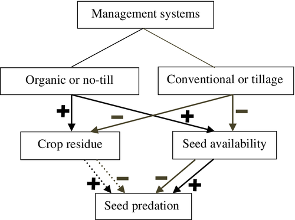

**Figure 1**

Diagrammatic presentation of interaction between management systems and seed predation (black arrows represent positive effects, and gray arrows represent negative effects).

### Crop type and its sequence

Studies of seed predation in several crops have been relatively consistent in identifying the greater importance of invertebrate compared to vertebrate seed predators (Gallandt *et al*. 2005). Cromar *et al*. (1999) inferred that invertebrates account for 80–90% of the seed predation in long-term tillage and crop rotation studies in maize, soybean (*Glycine max* L.), and wheat fields. They attributed 10–22% of total seed consumption to vertebrates. Similarly, Cardina *et al*. (1996) reported that vertebrates accounted for 13–15% of the velvetleaf (*Abutilon theophrasti* Medik.) predation in continuous maize fields. O'Rourke *et al*. (2006) found that within a field, seed predation rates varied depending on the crop type such as maize, soybean, or triticale-alfalfa (*Medicago sativa* L.) suggesting that differences in crop plant structure and management practice influence invertebrate activity-density and predation services (Labruyere *et al*. 2016a). Fox *et al*. (2013) reported that crop type had a significant effect on weed seed removal and invertebrate seed predator activity-density, so that Heggenstaller *et al*. (2006) and Meiss *et al*. (2010) showed that weed seed removal rates and activity-density of native invertebrate seed predators were lower following harvest in maize fields than in soybean and hay fields. Labruyere *et al*. (2016b) reported that oilseed rape field is of prime importance for the two spring breeders *Poecilus cupreus* (L.) and *Amara similata* (Gyll.) in terms of activity-density and nutritional state. Davis *et al*. (2013) also indicated that cumulative predation rates for the maize-soybean sequence were lower than in the soybean-wheat and wheat/red clover-maize sequence. In another research study, Westerman *et al*. (2005) estimated seed predation using models and concluded that weed control efficacy in soybean was 86% without allowing increases in velvetleaf density in 4-year rotation (maize-soybean-triticale + alfalfa-alfalfa) that received 82% less herbicides, whereas without predation, more than 97% control was required to prevent increases in velvetleaf density in 2-year rotation system (maize-soybean) managed with conventional rates of herbicides. Heggenstaller *et al*. (2006) indicated that seed predation in triticale intercrops with clover or alfalfa increased to moderate in autumn because of re-establishment of canopy cover by under seeded-legumes following triticale harvest. They stated that this strategy could be useful for enhancing autumn seed losses by predators. These observations support the theory that increased cover from crop residues after harvest such as in a hay field increases weed seed predation compared with a crop such as maize, which leaves a higher proportion of bare soil following harvest.

### Pesticide application

Today, many of pesticides are used to control pests and weeds in agricultural ecosystems, especially when pesticide tolerant-crops were produced that would be effective on beneficial organisms such as herbivores, parasitoids, arthropod pollinators, and weed seed predators. Factors such as species dispersal ability, availability of shelterbelts, and unsprayed buffer zones determine the ability of beneficial species to recover from insecticide applications and repopulate the field area (Holland & Luff 2000). For this purpose, chemical pesticides (e.g., insecticides, herbicides) should not be used or used in reduced doses within and field boundaries to control pests or weeds, because of the application of these pesticides result in mortality of positive organisms, especially weed seed predators or their food resources, where this method of weed suppression has been considered as a priority. For example, increased levels of weed control, primarily due to herbicide use, have resulted in reductions in wildlife, particularly birds (Moreby & Southway 1999; Marshall *et al*. 2003). Such population decline was attributed to reductions in the food supply, as weeds can serve as a direct food source (e.g., seeds) and as an indirect food source (e.g., supported arthropod fauna) for birds (Squire *et al*. 2003). Herbicide applications indirectly influence carabid populations through reduced food availability and habitat suitability (Brust 1990; Holland & Luff 2000). Also, adverse effects of fungicides can be measured in the form of reduced diversity of seed predators (Kulkarni *et al*. 2015). Trichard *et al*. (2013) recorded a negative impact of fungicides used for disease management on the Shannon diversity indices of granivorous species, whereas insecticides negatively affected total seed predation rates and the activity-density of omnivorous species. Therefore, studies on the impact of such pesticides in the process of seed predation and seed predator populations can give us valuable information for the advancement of weed management approaches. In contrast, no control of pests due to the conservation of seed predators, provides habitats for species of pests that attack the crops from adjacent of field. Classical examples of this type of interaction include pathogens, phytoplasmas, and viruses transmitted by leafhoppers, plant hoppers, whiteflies, aphids, and thrips (Alma *et al*. 2002). In this regard, it should take procedures without pesticides or lower rates of them to reduce the population of pests in these habitats and eliminate sources of damage to crops. A reduced dosage of field applications of insecticides and herbicides can help to maintain carabid activity (Navntoft *et al*. 2006). Some insecticides such as synthetic pyrethroids, which are considered less toxic to nontarget organisms, have been reported to cause sublethal toxicity among carabid species (Tooming *et al*. 2014).

## Habitat Structure

Habitat management is generally viewed as an important factor in maintaining stable insect and natural enemy populations in agricultural systems and may have a similar function in increasing weed seed predation (Landis *et al*. 2005). Habitat structure on the landscape scale (Menalled *et al*. 2000), field scale (Swanton *et al*. 1999), and local scale (Mittelbach & Gross 1984; Povey *et al*. 1993) affects the rates of seed predation. Spatial complexity of the landscape, field, and/or local scale as well as by predator preference, influences on seed predation patterns are shown in Fig. 2 (Booman *et al*. 2009).

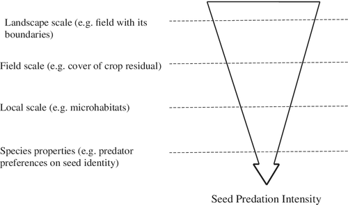

**Figure 2**

Hypothetical influences of spatial scale and functional properties of seed predators on seed predation levels over weed species. Arrow width indicating the relative weight of factors influencing predation patterns (retrieved from Booman *et al*. 2009).

### Landscape structure

A landscape does not necessarily refer to a large-scale study approach. Rather, the “landscape scale” is that at which the effects of the interactions among farming practices, land use, and agro-environmental processes on a given phenomenon become visible (Blaschke 2006); and this may vary from a field to a region. The landscape scale is a general concept, which does not give any numeric information about the size of the study area (Allen 1998); it just refers to the importance of continuous information exchange and transfers through upscaling and downscaling. This is particularly relevant to research on the relationships between agriculture and biodiversity (Barberi *et al*. 2010). There is growing evidence that increasing landscape complexity by including stable habitats such as natural vegetation bordering cultivated areas, unploughed refuges and hedgerows, interacts with highly disturbed annual crop fields in determining the within-field diversity and abundance of natural enemies (Zangger *et al*. 1994). Several studies have evaluated the impact of agricultural landscape structure on weed seed predation (Landis *et al*. 2005). Steffan-Dewenter *et al*. (2001) assessed the effects of agricultural landscape structure on predispersal seed predation of the brown knapweed (*Centaurea jacea* L.) and concluded that the proportion of flower heads damaged by seed predators increased with landscape complexity. Seed predation by rodents and earthworms was affected on the landscape scale, and seed predation by other invertebrates increased with higher habitat heterogeneity (Pufal & Klein 2015). Distribution patterns of seed predators and their granivory intensity could be affected by the removal of areas with permanent vegetation, used as refuges and food sources (Pollard & Relton 1970; Bilenca *et al*. 2007). Higher diversity, species richness, and abundance of wood mice (*Apodemus sylvaticus*) and common voles (*Microtus arvalis*) were observed in fallow habitats and crops providing long-term vegetation cover (Janova & Heroldova 2016). They also represented that fallow plots could play an important role in decreasing the negative impact of rodents on crops in intensively managed agricultural landscapes as they represent attractive year-round habitats for small mammals and act as winter refuges. These habitats also play an important role as refuges for other vertebrate and invertebrate species and, as such, act as centers of biodiversity. A generally positive effect of the cover of grassland and oilseed rape in the neighborhood demonstrated that in-field carabid abundance responds to the spatial distribution of agricultural land-use in the wider landscape (Labruyere *et al*. 2016a). Field boundaries existence can affect the content of seed predation by predators at the soil surface. As most seed predators need nonagricultural habitats at some stages of their lives (Pollard & Relton 1970; Birney *et al*. 1976), maintaining such areas could enhance weed seed loss (Menalled *et al*. 2000). Noncrop areas such as field boundaries are important habitats for seed predators, and these areas play an important role in supporting seed predators (Menalled *et al*. 2000; Saska *et al*. 2007). Grassy field margins had a positive effect on *P. rufipes* (DeG.) whose peak of activity occurred after crop harvest (Labruyere *et al*. 2016b). Gaines and Gratton (2010) stated that seed predation by small predators (i.e., ground beetles) was on average greater in the perennial noncrop habitat than within the potato fields. Perennial habitat has a greater plant structure and diversity and provides temporally stable resources, allowing beetle communities to become established over time (Bianchi *et al*. 2006). Ichihara *et al*. (2011) predicted that the degree of seed predation would be higher in the boundary strips than in the field interior areas because the boundary strips could be important habitats and refuge for seed predators to escape waterlogging and burning. The type of noncrop habitat is also important on seed consumption by predators. For example, seed removal rates are higher in fields surrounded by temporary pastures than fields surrounded by permanent pastures and forest (Trichard *et al*. 2013). Temporary pastures are more likely to be dynamic in terms of crop associations and the availability of food and shelter than permanent habitats (Kulkarni *et al*. 2015). Therefore, the intensity of weed seed predation might be decreased in simplified agricultural landscapes. A special type of refuge has been developed in the form of “beetle banks” (Thomas *et al*. 1992, 2002; Sotherton 1995; Collins *et al*. 2002). These consist of raised strips across crop field into which noncrop species, often grasses are sown. These sites increase farmland diversity and require minimal maintenance (Norris & Kogan 2005). Sown weed strips also seem to enhance beneficial insects, with a concomitant reduction in pest insects in adjacent fields (Hausammann 1996). From an IPM perspective, beetle banks should not use species that could be weedy in adjacent crops. Also, it is necessary that the plants in the beetle banks do not harbor organisms in other pest categories (Norris & Kogan 2005); dandelion noted to be present by Thomas *et al*. (2002) can be asymptomatic carriers of virus diseases. Complex habitats and ecotones generally promote favorable habitats for predators (Langellotto & Denno 2004; Denno *et al*. 2005), including many invertebrates (Thiele 1977) and small mammals (Larochelle 1975) that may prey upon carabids. However, Shearin *et al*. (2008) speculated that *H. rufipes* prefers vegetated environments because they afford protection from second-order predators. Birthisel *et al*. (2014) also reported that, contrary to expectation, second-order predation has the potential to negatively impact invertebrate seed predation rates in complex habitats than simple habitats. Overall, the effects of habitat complexity are locally specific and can range from having a very high effect to no effect at all on weed seed predation (Winqvist *et al*. 2011). A study by Jonason *et al*. (2013) showed that seed consumption rates by carabid beetles were higher in a simple landscape with a greater proportion of arable crops. Kulkarni *et al*. (2015) stated that an understanding of species dynamics on a given landscape scale concerning landscape characters is important. Management options could also be implemented at multiple spatial scales to promote weed seed predation in arable fields (Labruyere *et al*. 2016a).

### Field structure

As a field scale, leaving a portion of crop residue and cover-cropping practices, low or no-tillage may affect important groups of postdispersal weed seed predator populations (Gallandt *et al*. 2005). For example, Heggenstaller *et al*. (2006) indicated that leaving crop residues after harvest such as those seen in the fields of forage plants is leading to increased weed seed predation compared to maize field which higher proportion of residues is removed. Cutting compared to crop species has also indicated that the vegetation quantity (vegetation cover) was more important than vegetation quality (crop species) for seed predators (Meiss *et al*. 2010). Pufal and Klein (2013) reported that vegetation variables such as vegetation height and cover were significantly associated with seed predation rates. Navntoft *et al*. (2009) stated that cover-cropping practices increase the abundance of weed seed predation by various predators. As mentioned earlier, organic cropping practices (Dritschilo & Wanner 1980), especially cover cropping (Carmona & Landis 1999), perhaps conserves and increases the activity of invertebrate weed predators. The abundance of ground beetles (Coleoptera: Carabidae), which includes many species that feed on seeds, was greater on organic than on conventional fields (Dritschilo & Wanner 1980). Trichard *et al*. (2014) also indicated that the predation rate of the two species (*Veronica arvensis* and *Capsella bursa-pastoris*) were generally significantly higher in winter-wheat direct drilling with cover crop than in tillage system before harvest, but became lower in direct drilling than in tillage after harvest. Blubaugh *et al*. (2016) studies indicated that vegetative cover not only provides a favorable microclimate for natural enemies, but directly facilitates seed consumption. Thus, provisioning cover (e.g., cover crops and forage crops) may promote ecosystem services by weed seed predators, in addition to the numerous other benefits they provide. Nevertheless, above a certain level of plant cover (54–75%, depending on distance to field edges), seed removal rates started to decrease as the vegetation hindered predators' locomotion and made it difficult to find prey items. Similarly, crop and plant residues of any type could limit the activity of predators (Cromar *et al*. 1999; Jacob Spafford *et al*. 2006) and the ability to find seeds (Harrison *et al*. 2003).

### Microenvironment structure

Microhabitats could have a significant impact on the intensity of weed seed predation on a local scale, and alteration of the microenvironment can result in changes in arthropod populations. This might be related to the reproductive and demographic constraints imposed on mammal populations by seasonality in resource availability (Buckley *et al*. 2008; Williams & Middleton 2008). The vertebrate seed removal activity might be more dependent on local factors such as the presence of shrubs or trees, which act as refuges minimizing the predation risk (Brown 1992; Manson & Stiles 1998; Hurlbert & Haskell 2003; Garcia *et al*. 2011) than on broad-scale climatic variables (Peco *et al*. 2014). Peco *et al*. (2014) reported that seed removal by vertebrates was not related to mean annual evapotranspiration, but negatively (but weakly) related to rainfall seasonality. Invertebrate seed removal was positively related to mean annual evapotranspiration, but was even more strongly related to temperature. Saska *et al*. (2010) also reported that seed consumption by both sexes of *H. affinis* increased over a range of temperature or no response has been seen above the optimum temperature (20°C) by *P. rufipes*. Accordingly, Courtney and Kibota (1989) stated that plants growing in shady habitats had herbivore fauna different from those inhabiting sunny areas; light is attenuated with depth into the canopy, temperature is moderated; day-time temperatures are lower than ambient at the soil surface, and night-time temperatures are higher. Wind speed typically decreases with depth into the canopy, and relative humidity increases. Carbon dioxide concentration is lower in the canopy during the day and is higher at night (Norris & Kogan 2000). In agricultural systems, changing crop row spacing and crop density can generate microenvironments that can be effective on weed seed predation. Nurse *et al*. (2003) stated that reduced tillage and the narrow-row width would create microclimatic conditions within the plot that would favor the population of seed-feeding insects. In the more extensive level, Trichard *et al*. (2013) reported that landscape composition factors had a relatively higher influence than factors at the local practice level, such as no-tillage on weed seed predation service. They also suggested that weed management strategies should not only consider focusing on the management of individual fields but also on the surrounding landscapes to preserve predators biodiversity and enhance weed seed predation services.

## Conclusions

At first glance, it is clear that weed seed predators cannot remove all seeds of weed species, especially those that produce many seeds. Nevertheless, studies have shown that they can deplete weed seedbank over time if weed management programs designed effectively to avoid adding a greater number of seeds to seedbank annually. Seed predation on weed species that produce low densities of seeds can lead to a marked decline in their seedbanks and population dynamics in consecutive seasons. Predispersal seed predators have greater potential to predation of seeds before weeds can shed seeds on the soil surface. Predispersal seed predation should be combined with postdispersal seed predation by providing facilities for seed predators in agricultural ecosystems to significantly suppress weeds in succeeding years and depleting weed seedbanks. The net effect of seed predators will vary with weed species. While rodents appear to be the primary seed predators in some systems (Maron *et al*. 2012), ants and birds are important seed predators in others (Mares & Rosenzweig 1978; Inouye *et al*. 1980; Kelt *et al*. 2004), and different seed predator guilds can have very different effects on plant recruitment. Seed predators preferences may be affected by the size of the weed seeds. For example, while rodents tend to select for larger-seeded species, ants may tend to select for smaller-seeded species (Inouye *et al*. 1980; Ferreira *et al*. 2011). The size of the preferred seeds is known to be positively correlated with body mass, and small predators have difficulties in handling heavy and large seeds. Koprdova *et al*. (2010) reported that the head versus body size allometry might be important in seed consumption by predators such as millipedes, too. Chewing organs are massive in proportion to their body size, which enables them to handle relatively large seeds. Seed preferences may also be based on nutritional value differences, or seed coat strength and secondary metabolite profile, with significant intraspecific variation in palatability as well.

The studies reviewed here indicated that crop management practices such as tillage or disturbance result of a reduction in weed seed predator populations and their foraging behaviors. Habitat complexity plays an important role in increasing vertebrate and especially invertebrate seed predator populations. Incorporating perennial refuge space or strip-tillage practices that reduce soil disturbance between crop rows may improve safe-site limitations for overwintering larvae, and promote ecosystem services by following generations of weed seed predators (Blubaugh & Kaplan 2015). Also, delaying cultivation and tillage causes more availability of weed seeds for postdispersal seed predators on the soil surface at the end of the growing season and during autumn, winter, and early spring where there is no preference. Recommendations for enhancing weed seed predation services on-farm are to delay tillage until late in the fall or spring (Menalled 2008; Ward *et al*. 2008), and this strategy maximizes the time weed seeds are exposed to soil surface seed predators (Blubaugh & Kaplan 2015). Structural habitat determines predators retention and feeding behavior by providing shelter and refuge from predation (Landis *et al*. 2000; Kratina *et al*. 2012). Vegetative cover promotes a favorable microclimate (Magura *et al*. 2001), or provide habitats for carabid prey (Hawthorne & Hassall 1995). Hence, weed management programs should also aim to leave crop residues in crop fields at the end of the growing season after crop harvest to generate microhabitats for predators when weed seeds shed. Based on Birthisel *et al*. (2014) studies, habitat complexity is an important driver of second-order predation rates, too. This is the reason that seed predators are seen in high densities in field boundaries or undisturbed places compared to within arable fields. Therefore, field boundaries should also be protected to return predators at the end of the growing season and come back to crop fields during the growing season. In these places, predators can refer to their refuges from the enemies, severe sunlight, etc. For this purpose, chemical pesticides should not be used within and field boundaries to control pests or weeds. Adoption of methods in agricultural operations that caused to preserve or increase in weed seed predator populations must be considered as integrated weed management approaches in agricultural ecosystems. According to this, a single strategy cannot have a remarkable effect on weed seed suppression, but several strategies should be considered to a substantial reduction in weed seedbanks by providing facilities for predators based on seed predator species and ecosystem structure.

## Future Research

Despite many studies conducted about the potential of seed predators reducing weed seeds; some researchers have suggested invertebrates, especially carabids have an important role reducing weed seedbanks in agricultural ecosystems, but several studies should be done on a landscape scale, especially in complex habitats, wide range of weather and soil conditions, crop types and their weeds, and appropriate crop rotations to understand more about foraging behaviors of weed seed predators. Most studies have been conducted on postdispersal seed predators, while the best time to reduce the population of weed seeds in the soil seedbanks is before depleting their seeds. Therefore, evaluations should also be carried out on the ability of predators to prey on weed seeds, especially about worst weeds and weeds producing a large number of seeds before they can shed seeds on the soil surface. The active time of weed seed predation influences weed population dynamics. Because of the susceptibility of weed seeds to predation and easier control of seeds by predators in the seed formation stage, necessary steps should be taken to maximize predators populations at this time. On the other hand, total seed loss due to predispersal predation depends on the overlap in the patterns of seed predation and seed formation. Accordingly, studies in this field can provide more knowledge on weed control at this growth stage and consequently necessary facilities for this synchrony. While the effects of CO<sub>2</sub> on biological control may vary accordingly, the general patterns of decreased plant quality (particularly through increases in the C:N ratio), insect preference and synchrony of plant, and biological control agent phenologies with elevated CO<sub>2</sub> may not bode well for biological control applications. Therefore, weed control specialist should pay more attention to the effects of CO<sub>2</sub> on biological control agents. Finally, Seed predation can be an important biotic filter affecting plant establishment via differences in consumer preferences and abundance with important ramifications for plant invasions and in situ community assembly (Connolly *et al*. 2014). Rodent seed predation appears to be an important general source of resistance to plant invasion (Brown & Heske 1990; Pierson & Mack 1990; Reader 1993; Pearson *et al*. 2011, 2012; Maron *et al*. 2012). Due to plant invasions, this potential could be used to prevent and suppress invasive weeds in future studies.

## Disclosure Statement

The author declares no conflict of interest.

## Citing Literature

[figure not shown]

[Volume19, Issue3](https://onlinelibrary.wiley.com/toc/14456664/2019/19/3)

September 2019

Pages 61-74

[figure not shown]